# kits 的演算法 6：量尺的性質

## 0 這份教學

校準、計分、連結和常模（01–04）做好以後，量尺本身還有幾個問題要問：

1. 一個題本在量尺的每個位置量得多準？（第 2、3 節：訊息、精準度）
2. 兩個題本的原始分怎麼對照？（第 4 節；分量表在 07）
3. 所有世代放在同一條量尺上，成長和分散看起來合理嗎？（第 5 節：垂直量尺）
4. 世代連結和不用共同題的算法一致嗎？（第 6 節：連結檢查）
5. kits 和 kitsPreview（dexter、cNORM）給同樣的數字嗎？（第 7 節）

你會學到：

- 每一步是做什麼用的，和它的公式（數學式，和可以一鍵複製的 `latex` 區塊）。
- 在模擬資料上一步一步手算，和 kits、`algo_` 的結果比（印出 `TRUE`）。
- 教學程式 `information.R` 在哪一段，和怎麼執行。
- 貼到新的 R 就能重做的流程（第 8 節）。

你需要：

- 01 校準、02 計分（WLE）、03 連結（mean/sigma、連結誤差）。
- 模型的程式在 kits 的模型；這裡指過去，不重複。
- 套件：kits，和 dplyr、tidyr、purrr、tibble、ggplot2（`library()` 這六個）。

### 0.1 小工具

和 05 相同的四個小工具。 `script_part()` 讀出教學程式的一段：

````r
script_part <- function(file, part) {
  lines <- readLines(system.file("scripts", file, package = "kits"))
  start <- grep(sprintf("^# ==== part: %s ====", part), lines)
  if (length(start) != 1) stop("no part ", part, " in ", file)
  marks <- grep("^# ==== ", lines)
  end <- c(marks[marks > start], length(lines) + 1)[1] - 1
  cat("```r", lines[start:end], "```", sep = "\n")
}
````

`run_script()` 在新的環境裡執行整份教學程式：

```r
run_script <- function(file) {
  env <- new.env(parent = globalenv())
  path <- system.file("scripts", file, package = "kits")
  printed <- capture.output(suppressMessages(sys.source(path, envir = env)))
  env
}
```

`run_fresh()` 把這份文件的程式區塊（一個或幾個）放到只有 `library(kits)` 的新 R 裡執行：

```r
run_fresh <- function(labels) {
  code <- paste(unlist(map(labels, knitr::knit_code$get)), collapse = "\n")
  callr::r(\(code) {
    library(kits)
    eval(parse(text = code), envir = globalenv())
  }, args = list(code = code))
}
```

`same()` 容許 $10^{-12}$ 的相對誤差（加總的順序不同）；完全相同的地方用 `identical()`。

```r
same <- function(a, b, tol = 1e-12) {
  isTRUE(all.equal(as.vector(a), as.vector(b), tolerance = tol))
}
```

### 0.2 演算法一覽

```r
kits_algorithm("information")
```

```
#> <kits_algorithm> information: information, expected score and precision of a form
#> Steps:
#>   1. PCM probabilities of each item
#>        P_ik(θ) = exp(kθ − Σ_{g≤k} β_ig) / Σ_h exp(hθ − Σ_{g≤h} β_ig)
#>   2. Test information (kits_information())
#>        I(θ) = Σ_i Σ_k (k − E_i)² P_ik,  E_i = Σ_k k P_ik
#>   3. Expected raw score (kits_expected_score()); RTMB checks its slope
#>        E(θ) = Σ_i E_i(θ),  dE/dθ = I(θ)
#>   4. Raw-score distribution of a form (Lord-Wingersky)
#>        f_j(x | θ) = Σ_k f_{j−1}(x − k | θ) P_jk(θ)
#>   5. Bias and RMSE of the WLE (kits_precision()); usable where RMSE < criterion
#>        bias = Σ_r P(r | θ) θ̂(r) − θ,  RMSE = √(bias² + SD²)
#> Components:
#>   kits_information(item)(theta), kits_expected_score(item)(theta)
#>   kits_precision(item, forms)
#>   algo_cml(kits_stats(X))$betas |> algo_lw(theta = theta)    # raw-score distribution
#>   inside: pcm_function(), tcc(), form_precision()
#> References:
#>   Lord, F. M., & Wingersky, M. S. (1984). Applied Psychological Measurement, 8, 453-461.
#>   Thissen, D., Pommerich, M., Billeaud, K., & Williams, V. S. L. (1995). Appl. Psychol. Meas., 19, 39-49.
#>   Kolen, M. J., & Brennan, R. L. (2014). Test equating, scaling, and linking (3rd ed.). Springer.
#>   Warm, T. A. (1989). Psychometrika, 54, 427-450.
#> Read more:
#>   tutorial_algorithms/06_scale.html
#>   system.file("scripts", "information.R", package = "kits"), parts: information, expected_score
```

第 2、3 節照這些步驟做一次。

## 1 資料

一個領域，10 題；第 1、4、9 題兩點計分，其他三點計分。

```r
set.seed(7)
b <- seq(-2.5, 3, length.out = 10)
betas <- map(b, \(x) x + c(-0.5, 0.5))
betas[c(1, 4, 9)] <- b[c(1, 4, 9)]
names(betas) <- sprintf("lan%02d", 1:10)
```

兩個世代：M03 有 12、24、36 個月三波，M36 有 36、48 個月兩波。 兩個世代都有 36 個月（第 5、6 節要用）。

```r
persons <- tibble(cohort = rep(c("M03", "M36"), c(600, 400)),
                  wave_m = rep(c(12, 24, 36, 36, 48), each = 200)) |>
  mutate(visit_id = paste(cohort, wave_m, 1:200, sep = "_"),
         age_m = wave_m + runif(n(), -1, 1),
         sex = sample(c("boy", "girl"), n(), replace = TRUE))
theta <- 1.8 * log(persons$age_m / 12) + rnorm(1000, 0, 0.9)
m03 <- persons$cohort == "M03"
```

M03 答第 1–8 題（12 個月不答第 7、8 題，36 個月不答第 1、2 題），M36 答第 5–10 題：

```r
X03 <- kits_sim(theta[m03], betas[1:8], seed = 1)
rownames(X03) <- persons$visit_id[m03]
w03 <- persons$wave_m[m03]
X03[w03 == 12, c("lan07", "lan08")] <- NA
X03[w03 == 36, c("lan01", "lan02")] <- NA
X36 <- kits_sim(theta[!m03], betas[5:10], seed = 2)
rownames(X36) <- persons$visit_id[!m03]
```

校準、計分，再把 M36 連結到 M03 的量尺（03）：

```r
item03 <- kits_item(X03, scale = "lan M03")
item36 <- kits_item(X36, scale = "lan M36")
co <- kits_linking(item36, item03, n_boot = 200)
s03 <- kits_subj(X03, item03, persons = persons)
s36 <- kits_subj(X36, item36, persons = persons)
```

手算用的步驟參數，一題一個向量（`algo_cml()` 和 `kits_item()` 是同一個 CML）：

```r
beta_of <- (kits_stats(X03) |> algo_cml())$betas
identical(unlist(beta_of, use.names = FALSE), coef(item03)$beta)
```

```
#> [1] TRUE
```

## 2 訊息和期望分數

### 2.1 做什麼用

訊息 $I(\theta)$ 說的是：在能力 $\theta$ 附近，這些題分得多開。 訊息大，估計的 SE 小（約 $1/\sqrt{I}$）。 期望分數（測驗特徵曲線）是能力 $\theta$ 的孩子平均拿幾分；第 4 節的真分數等化用它。 兩個都只用題目參數，不用孩子的資料。

### 2.2 公式

$$P_{ik}(\theta) = \frac{\exp(k\theta - \sum_{g=1}^{k}\beta_{ig})}{\sum_{h=0}^{m_i}\exp(h\theta - \sum_{g=1}^{h}\beta_{ig})},\quad
E_i(\theta) = \sum_k k\,P_{ik},\quad
I(\theta) = \sum_i \sum_k (k - E_i)^2 P_{ik},\quad
\frac{d}{d\theta}\sum_i E_i(\theta) = I(\theta)$$

```latex
P_{ik}(\theta) = \frac{\exp(k\theta - \sum_{g=1}^{k}\beta_{ig})}{\sum_{h=0}^{m_i}\exp(h\theta - \sum_{g=1}^{h}\beta_{ig})},\quad
E_i(\theta) = \sum_k k\,P_{ik},\quad
I(\theta) = \sum_i \sum_k (k - E_i)^2 P_{ik},\quad
\frac{d}{d\theta}\sum_i E_i(\theta) = I(\theta)
```

- 一題的訊息就是它分數的變異數（PCM）。
- 期望分數的斜率就是訊息。
- 訊息的斜率 $I'(\theta)$ 是每題分數的三階中央動差加起來；kits 用 RTMB 自動微分（模型教學 第 9.1 節）。

### 2.3 手算

一題在一個 $\theta$ 的類別機率：

```r
pcm <- function(theta, beta) {
  eta <- cumsum(c(0, theta - beta))
  exp(eta - max(eta)) / sum(exp(eta - max(eta)))
}
pcm(0.5, beta_of$lan02)
```

```
#> [1] 0.01307792 0.14179951 0.84512257
```

每題的期望分數和變異數，加起來：

```r
th <- c(-4, -2, 0, 2, 4)
item_E <- function(t, beta) sum(seq_along(pcm(t, beta)) * pcm(t, beta)) - 1
item_V <- function(t, beta) sum((seq_along(pcm(t, beta)) - 1 - item_E(t, beta))^2 * pcm(t, beta))
E_hand <- map_dbl(th, \(t) sum(map_dbl(beta_of, \(b) item_E(t, b))))
I_hand <- map_dbl(th, \(t) sum(map_dbl(beta_of, \(b) item_V(t, b))))
```

斜率用數值微分看一次：

```r
h <- 1e-5
E_at <- function(t) sum(map_dbl(beta_of, \(b) item_E(t, b)))
slope_num <- map_dbl(th, \(t) (E_at(t + h) - E_at(t - h)) / (2 * h))
same(slope_num, I_hand, tol = 1e-8)
```

```
#> [1] TRUE
```

數值微分的誤差約 $h^2$，所以這裡容許 $10^{-8}$。

### 2.4 用 kits 和 `algo_`

`kits_information()`、`kits_expected_score()` 各回傳一個 $\theta$ 的函數：

```r
info03 <- kits_information(item03)
expected03 <- kits_expected_score(item03)
c(information = same(info03(th), I_hand), expected = same(expected03(th), E_hand))
```

```
#> information    expected
#>        TRUE        TRUE
```

`algo_pcm()` 是一題的核心；把每題的 `Var`、`E` 加起來，和 kits 完全相同：

```r
I_algo <- map(beta_of, \(b) algo_pcm(th, b)$Var) |> reduce(`+`)
E_algo <- map(beta_of, \(b) algo_pcm(th, b)$E) |> reduce(`+`)
c(identical(I_algo, info03(th)), identical(E_algo, expected03(th)))
```

```
#> [1] TRUE TRUE
```

`kits_pcm_prob()` 一次給機率、每題的動差，和整個測驗的三個數字：

```r
pp <- kits_pcm_prob(item03, th)
pp$test
```

```
#>   theta expected information information_slope
#> 1    -4     0.49        0.45              0.38
#> 2    -2     2.54        1.73              0.73
#> 3     0     6.98        2.48              0.05
#> 4     2    11.46        1.74             -0.72
#> 5     4    13.52        0.45             -0.39
```

```r
M3 <- map(beta_of, \(b) algo_pcm(th, b, third = TRUE)$M3) |> reduce(`+`)
same(M3, pp$test$information_slope)
```

```
#> [1] TRUE
```

`information_slope` 是 RTMB 對 $I(\theta)$ 的導數；它等於三階中央動差的和。

### 2.5 教學程式：`information.R`

分兩段：`information`（第 1 步）和 `expected_score`（第 2–3 步，RTMB 驗證斜率就是訊息）。

```r
script_part("information.R", "expected_score")
# ==== part: expected_score ====
# 2 The expected raw score: sum_i E(X_i | theta), E(X_i | theta) = sum_k k P_ik
expected_one <- function(t) {
  total <- 0
  for (beta_i in beta_of) total <- total + sum(seq_along(beta_i) * pcm(t, beta_i)[-1])
  total
}
expected_score <- function(theta) map_dbl(theta, expected_one)
expected_score(theta)

# 3 Its slope is the information: d E(X | theta) / d theta = I(theta), the slope from RTMB
slope <- map_dbl(theta, \(t) MakeTape(expected_one, t)$jacobian(t))
max(abs(slope - information(theta)))
```

它在示範資料 `kitm03` 上執行，最後和 kits 比：

```r
env_info <- run_script("information.R")
env_info$diffs
```

```
#>  information     expected
#> 9.325873e-15 3.552714e-15
```

```r
all(env_info$diffs < 1e-10)
```

```
#> [1] TRUE
```

```r
max(abs(env_info$slope - env_info$information(env_info$theta)))
```

```
#> [1] 1.099121e-14
```

## 3 精準度：`kits_precision()`

### 3.1 做什麼用

訊息說的是「大約」多準。 `kits_precision()` 問得更直接：真正能力是 $\theta$ 的孩子答這個題本，他的 WLE 平均落在哪、散多開？ 它不用模擬，用 Lord–Wingersky 遞迴算出每個原始分的機率，再加總。

### 3.2 公式

原始分的分布，一題一題加上去：

$$f_j(x \mid \theta) = \sum_{k=0}^{m_j} f_{j-1}(x - k \mid \theta)\, P_{jk}(\theta),\quad f_0(0 \mid \theta) = 1$$

```latex
f_j(x \mid \theta) = \sum_{k=0}^{m_j} f_{j-1}(x - k \mid \theta)\, P_{jk}(\theta),\quad f_0(0 \mid \theta) = 1
```

WLE 的平均、偏誤、SD 和 RMSE：

$$E[\hat\theta \mid \theta] = \sum_r P(r \mid \theta)\,\hat\theta(r),\quad
\mathrm{bias} = E[\hat\theta \mid \theta] - \theta,\quad
\mathrm{SD} = \sqrt{\sum_r P(r \mid \theta)\,\hat\theta(r)^2 - E^2},\quad
\mathrm{RMSE} = \sqrt{\mathrm{bias}^2 + \mathrm{SD}^2}$$

```latex
E[\hat\theta \mid \theta] = \sum_r P(r \mid \theta)\,\hat\theta(r),\quad
\mathrm{bias} = E[\hat\theta \mid \theta] - \theta,\quad
\mathrm{SD} = \sqrt{\sum_r P(r \mid \theta)\,\hat\theta(r)^2 - E^2},\quad
\mathrm{RMSE} = \sqrt{\mathrm{bias}^2 + \mathrm{SD}^2}
```

- $\hat\theta(r)$：這個題本原始分 $r$ 的 WLE（0 分和滿分也有）。
- SD 就是條件測量標準誤（Kolen & Brennan, 2014, pp. 463-464）。
- 可用範圍：RMSE 最小的點周圍、連續的一段格點，RMSE 小於 `criterion`（預設 1 logit）。 RMSE 1 logit 在 SD 是 $s$ 的孩子裡，信度約 $1 - 1/s^2$。

### 3.3 手算

加上一題：`f` 是前面幾題的分布（一列一個 $\theta$），`P` 是這一題的類別機率。

```r
add_item <- function(f, P) {
  g <- matrix(0, nrow(f), ncol(f) + ncol(P) - 1)
  for (k in seq_len(ncol(P)) - 1) {
    cols <- seq_len(ncol(f)) + k
    g[, cols] <- g[, cols] + f * P[, k + 1]
  }
  g
}
```

從 0 題（原始分一定是 0）開始，一題一題加：

```r
lw <- function(theta, items) {
  f <- matrix(1, length(theta), 1)
  for (i in items) f <- add_item(f, t(sapply(theta, pcm, beta = beta_of[[i]])))
  f
}
```

先在一個很小的題本（lan01、lan02、lan04）上看它對不對：只有 $2 \times 3 \times 2 = 12$ 種分數組合，可以直接列出來。

```r
tiny <- c("lan01", "lan02", "lan04")
grid <- expand.grid(lan01 = 0:1, lan02 = 0:2, lan04 = 0:1)
one_pattern <- function(t, x) prod(map2_dbl(tiny, x, \(i, k) pcm(t, beta_of[[i]])[k + 1]))
prob_of <- function(t) apply(grid, 1, \(x) one_pattern(t, x))
by_enum <- tapply(prob_of(0.5), rowSums(grid), sum)
same(by_enum, lw(0.5, tiny))
```

```
#> [1] TRUE
```

24 個月的題本（lan01–lan08），每個原始分的 WLE 用 `algo_jme()`：

```r
form24 <- sprintf("lan%02d", 1:8)
grid_theta <- seq(-6, 6, by = 0.1)
P_r <- lw(grid_theta, form24)
wle_r <- algo_jme(beta_of[form24])$theta
same(P_r, algo_lw(grid_theta, beta_of[form24]))
```

```
#> [1] TRUE
```

照公式算平均、SD、RMSE：

```r
expected <- drop(P_r %*% wle_r)
sd_hat <- sqrt(drop(P_r %*% wle_r^2) - expected^2)
rmse <- sqrt((expected - grid_theta)^2 + sd_hat^2)
```

可用範圍：從 RMSE 最小的點往兩邊走，直到 RMSE 不再小於 1。

```r
best <- which.min(rmse)
ok <- rmse < 1
lo <- hi <- best
while (lo > 1 && ok[lo - 1]) lo <- lo - 1
while (hi < length(ok) && ok[hi + 1]) hi <- hi + 1
c(from = grid_theta[lo], to = grid_theta[hi], min_rmse = rmse[best])
```

```
#>       from         to   min_rmse
#> -4.6000000  4.5000000  0.6342155
```

### 3.4 用 kits

`forms` 給 `kits_subj_table()` 的結果，就是每個波次的標準題本：

```r
tab03 <- kits_subj_table(s03)
prec <- kits_precision(item03, tab03)
prec
```

```
#> <kits_precision> 3 form(s), 121 theta values each; scale: lan M03
#> Usable range (RMSE < 1):
#>     form n_items max_raw  from   to min_rmse    at
#>  wave 12       6      10 -4.50 3.10     0.69 -0.70
#>  wave 24       8      14 -4.60 4.50     0.63  0.10
#>  wave 36       6      11 -3.50 4.50     0.67  0.60
#> The curves: as.data.frame(x); plot(x).
#> Checks: OK
```

和手算比：

```r
p24 <- filter(as.data.frame(prec), form == "wave 24")
r24 <- filter(attr(prec, "ranges"), form == "wave 24")
c(expected = same(expected, p24$expected), sd = same(sd_hat, p24$sd), rmse = same(rmse, p24$rmse),
  range = same(c(grid_theta[lo], grid_theta[hi]), c(r24$from, r24$to)))
```

```
#> expected       sd     rmse    range
#>     TRUE     TRUE     TRUE     TRUE
```

三個題本的 RMSE 曲線：

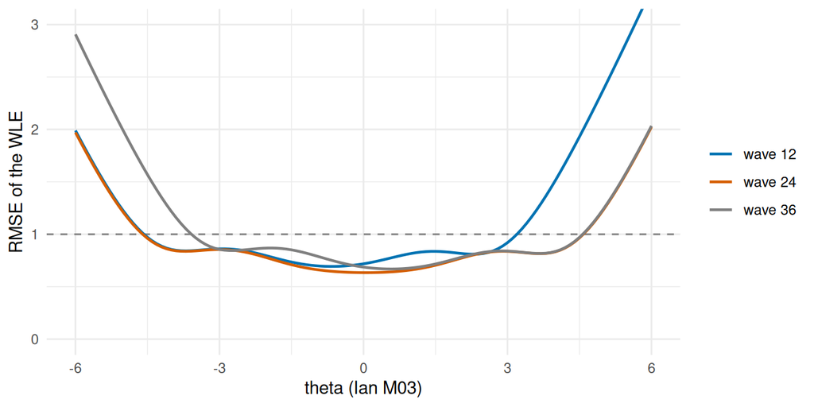

```r
ggplot(as.data.frame(prec), aes(theta, rmse, colour = form)) +
  geom_hline(yintercept = 1, colour = "#7F7F7F", linetype = "dashed") +
  geom_line(linewidth = 0.8) +
  scale_colour_manual(values = c("#0072B2", "#D55E00", "#7F7F7F")) +
  coord_cartesian(ylim = c(0, 3)) +
  labs(x = "theta (lan M03)", y = "RMSE of the WLE", colour = NULL) +
  theme_minimal()
```

量尺兩端的 RMSE 比中間大很多：題本只在中間量得準。 `link =` 把結果換到另一條量尺（例如 D）；`criterion` 預設也跟著乘上斜率。

## 4 原始分對照：`kits_subj_table()` 加 `kits_expected_score()`

### 4.1 做什麼用

12 個月的題本（lan01–lan06）拿 5 分，等於 36 個月的題本（lan03–lan08）的幾分？

kits 用 $\theta$ 計分，所以其實不需要這張表。 用 IRT 的能力計分時，兩個題本的分數之間不必再建立關係（Kolen & Brennan, 2014, §6.4, p. 191）。 PCM 的原始分是充分統計量：同一個題本，原始分相同，$\theta$ 就相同。 所以原始分 → $\theta$ 的換算表（`kits_subj_table()`，02）本身就是計分。

對照表只是幫忙讀原始分，分兩步：

1. F 題本的原始分 → $\theta$（換算表）。
2. $\theta$ → T 題本的期望分數（第 2 節的 `kits_expected_score()`）。

兩個題本的題目在同一個校準裡，所以兩步都在同一條量尺上。

### 4.2 公式

T 題本的真分數 $T_T(\theta)$ 是它的期望總分；F 題本原始分 $r$ 的對照分數：

$$e(r) = T_T\big(\hat\theta_F(r)\big),\quad T_T(\theta) = \sum_{i \in T} E_i(\theta);\qquad
\text{MLE: } \hat\theta_F(r) = T_F^{-1}(r),\ 0 < r < K_F;\quad e(0) = 0,\ e(K_F) = K_T$$

```latex
e(r) = T_T\big(\hat\theta_F(r)\big),\quad T_T(\theta) = \sum_{i \in T} E_i(\theta);\qquad
\text{MLE: } \hat\theta_F(r) = T_F^{-1}(r),\ 0 < r < K_F;\quad e(0) = 0,\ e(K_F) = K_T
```

- $K_F$、$K_T$：兩個題本的滿分。
- 真分數等化（Kolen & Brennan, 2014, §6.5, pp. 192-197）解 $T_F(\theta) = r$。 PCM 的這個解就是 MLE；0 分和滿分沒有解，所以直接 0 對 0、滿分對滿分。
- kits 的換算表用 WLE（Warm, 1989）：0 分和滿分也有 $\theta$。 所以 $e(0)$ 大於 0，$e(K_F)$ 小於 $K_T$；兩種差最多的是兩端（第 4.4 節的例子）。
- 真分數的關係本來是真分數對真分數。 拿它來換觀察到的原始分，沒有理論上的根據；它的根據是實證的：和觀察分數等化的結果很接近（§6.5.4, pp. 196-197；Lord & Wingersky, 1984）。
- 它只用題目參數，不依賴孩子的能力分布（§6.7, p. 201）。

另一種做法是觀察分數等化（§6.6, pp. 198-200）。 它用 Lord–Wingersky 遞迴（第 3 節）算出兩個題本原始分的分布，對一個能力分布平均，再用等百分位對齊。 它要先選一個能力分布；KIT 各波次的能力差很多，選 12 個月或 36 個月的孩子，答案就不同，所以這裡用真分數。

### 4.3 手算

兩個題本，和一個題本的真分數 $T(\theta)$：

```r
from12 <- sprintf("lan%02d", 1:6)
to36 <- sprintf("lan%02d", 3:8)
tcc <- function(t, items) sum(map_dbl(beta_of[items], \(b) item_E(t, b)))
```

MLE：`uniroot()` 找 $T_F(\theta) = r$ 的 $\theta$。 WLE：每個原始分的 WLE 用 `algo_jme()`（第 3.3 節也用它）。 兩種 $\theta$ 都再算 T 題本的期望分數：

```r
theta_of_raw <- function(r) uniroot(\(t) tcc(t, from12) - r, c(-20, 20), tol = 1e-12)$root
K12 <- sum(lengths(beta_of[from12]))
theta_r <- map_dbl(1:(K12 - 1), theta_of_raw)
equiv_mle <- c(0, map_dbl(theta_r, tcc, items = to36), sum(lengths(beta_of[to36])))
wle_12 <- algo_jme(beta_of[from12])$theta
equiv_wle <- map_dbl(wle_12, tcc, items = to36)
```

### 4.4 用 kits

第 3.4 節的 `tab03` 已經有每一波標準題本的換算表；12 個月的標準題本就是 lan01–lan06。

```r
tab12 <- filter(tab03, wave_m == 12)
expected36 <- kits_expected_score(item03, items = to36)
equiv_kits <- expected36(tab12$theta)
```

和手算比：

```r
forms12 <- filter(attr(tab03, "forms"), wave_m == 12, form == 1)
c(form = identical(forms12$items, toString(from12)), theta = same(tab12$theta, wle_12, tol = 1e-8),
  equivalent = same(equiv_kits, equiv_wle))
```

```
#>       form      theta equivalent
#>       TRUE       TRUE       TRUE
```

MLE 和 WLE 兩種對照放在一起：

```r
tibble(raw = tab12$raw, theta_MLE = c(-Inf, theta_r, Inf), theta_WLE = tab12$theta,
       e_MLE = equiv_mle, e_WLE = equiv_kits) |>
  mutate(across(-raw, \(x) round(x, 2)))
```

```
#> # A tibble: 11 × 5
#>      raw theta_MLE theta_WLE e_MLE e_WLE
#>    <int>     <dbl>     <dbl> <dbl> <dbl>
#>  1     0   -Inf        -4.13  0     0.17
#>  2     1     -3.17     -2.83  0.41  0.56
#>  3     2     -2.29     -2.14  0.91  1.03
#>  4     3     -1.68     -1.61  1.49  1.57
#>  5     4     -1.16     -1.13  2.17  2.21
#>  6     5     -0.67     -0.67  2.98  2.98
#>  7     6     -0.18     -0.21  3.94  3.89
#>  8     7      0.34      0.27  5.06  4.92
#>  9     8      0.94      0.8   6.41  6.1
#> 10     9      1.8       1.47  8.16  7.53
#> 11    10    Inf         2.69 11     9.5
```

- 中間的分數，兩個 $\theta$ 很接近，對照分數也很接近。
- 兩端 WLE 往中間拉：0 分對到 0.17 分，滿分對到 9.5 分（滿分 11）。
- `kits_subj_table()` 和 `algo_jme()` 都是疊代到容許誤差就停，所以兩邊的 WLE 比較時容許 $10^{-8}$。

### 4.5 沒有共同題也可以

兩個題本自己不必有共同題，只要它們的題目在**同一條量尺**上。 同一條量尺是校準（或連結）給的：共同題可以在中間的波次，把整條鏈串起來。

示範資料 `kitm03` 的語言：3–24 個月答 lana01–06，36–72 個月答 lanb01–09，兩組沒有共同題。 lanc01–09 在 3、6 個月只有一、兩題，12 到 72 個月九題都答，所以全部在同一個校準裡：

```r
lan03 <- kitm03$responses |> filter(domain == "lan") |> kits_resp()
item_lan <- kits_item(lan03, scale = "lan M03")
items_a <- sprintf("lana%02d", 1:6)
items_b <- sprintf("lanb%02d", 1:9)
intersect(items_a, items_b)
```

```
#> character(0)
```

lana01–06 不是任何一波的標準題本，所以把它的題目參數挑出來，給 `kits_subj_table()`：

```r
tab_a <- kits_subj_table(filter(coef(item_lan), item_id %in% items_a))
expected_b <- kits_expected_score(item_lan, items = items_b)
tibble(raw = tab_a$raw, theta = round(tab_a$theta, 2), lanb = round(expected_b(tab_a$theta), 2))
```

```
#> # A tibble: 19 × 3
#>      raw theta  lanb
#>    <int> <dbl> <dbl>
#>  1     0 -6.14  0.01
#>  2     1 -5.01  0.04
#>  3     2 -4.51  0.07
#>  4     3 -4.13  0.1
#>  5     4 -3.8   0.14
#>  6     5 -3.52  0.19
#>  7     6 -3.27  0.24
#>  8     7 -3.06  0.3
#>  9     8 -2.87  0.36
#> 10     9 -2.69  0.44
#> 11    10 -2.51  0.53
#> 12    11 -2.31  0.65
#> 13    12 -2.1   0.81
#> 14    13 -1.86  1.04
#> 15    14 -1.57  1.42
#> 16    15 -1.24  2
#> 17    16 -0.91  2.8
#> 18    17 -0.54  4
#> 19    18  0.09  6.64
```

- 這張對照表只用題目參數：每一波都一樣。
- 這兩份題目難度差很多：lana 的 0–12 分都對到 lanb 的不到 1 分，lana 滿分只對到 lanb 的 6.6 分（滿分 27）。 能力落在兩份題目都量得到的地方時，對照才可靠；兩份題目幾乎不重疊時，這張表大部分是外插。
- 兩份題目給的年齡差很多時，比 $\theta$（或 D）比對照原始分好（02）。

**不必限定題本。** 任何兩組題目，只要在同一條量尺上，都可以這樣對照：整個領域的題本、一個分量表，或自己挑的一組題。 意思是「平均而言」：$\theta$ 相同的孩子，在 F 題本的原始分是 $r$，在 T 題本的期望分數是 $e(r)$；個別孩子的原始分仍有誤差，兩份題本的信度也不同。 原始分是每題分數的加總（一題 0–3 或 0–4 分），不是答對幾題。 跨波次比較一個分量表的分數，和它的 SE、成長模型、模擬檢查，在 07 分量表。

### 4.6 兩個世代：經過連結

M36 的 84 個月題本（含 land 題）在 M36 的校準裡，lanb 在 M03 的校準裡。 接起來要三步：原始分 → M36 的 $\theta$ → 連結 $\theta_{03} = B + A\,\theta_{36}$ → M03 題本的期望分數。

```r
lan36 <- kitm36$responses |> filter(domain == "lan") |> kits_resp()
item_lan36 <- kits_item(lan36, scale = "lan M36")
co_lan <- kits_linking(item_lan36, item_lan)
booklet_84 <- kitm36$responses |>
  filter(domain == "lan", wave_m == 84) |>
  count(item_id) |>
  filter(n >= 0.5 * max(n)) |>
  pull(item_id)
```

手算（MLE）：

```r
betas_of <- function(item) split(coef(item)$beta, coef(item)$item_id)
tcc_of <- function(t, betas) sum(map_dbl(betas, \(b) item_E(t, b)))
b84 <- betas_of(item_lan36)[booklet_84]
bb <- betas_of(item_lan)[items_b]
K84 <- sum(lengths(b84))
```

```r
theta36 <- map_dbl(1:(K84 - 1), \(r) uniroot(\(t) tcc_of(t, b84) - r, c(-20, 20), tol = 1e-10)$root)
theta03 <- co_lan$intercept + co_lan$slope * theta36
tibble(raw_84m = 1:(K84 - 1), theta_M03 = round(theta03, 2),
       lanb_equivalent = round(map_dbl(theta03, tcc_of, betas = bb), 2)) |>
  slice(seq(1, K84 - 1, by = 5))
```

```
#> # A tibble: 15 × 3
#>    raw_84m theta_M03 lanb_equivalent
#>      <int>     <dbl>           <dbl>
#>  1       1     -1.75            1.17
#>  2       6      0.32            7.77
#>  3      11      1.24           12.1
#>  4      16      1.88           15
#>  5      21      2.39           17.4
#>  6      26      2.83           19.6
#>  7      31      3.24           21.5
#>  8      36      3.64           23.1
#>  9      41      4.04           24.3
#> 10      46      4.46           25.2
#> 11      51      4.91           25.9
#> 12      56      5.43           26.4
#> 13      61      6.06           26.7
#> 14      66      6.95           26.9
#> 15      71      8.95           27.0
```

- 用 WLE 也是同樣三步：`kits_subj_table()` 給 M36 的 $\theta$，代入連結的直線 $\theta_{03} = B + A\,\theta_{36}$，再給 `kits_expected_score(item_lan, items = items_b)`。
- `kits_convert()` 換過的題目表不能直接用：它換了門檻，`beta` 還在 M36 的量尺。 `kits_expected_score()` 和 `kits_subj_table()` 用的是 `beta`，所以它們的 $\theta$ 仍是 M36 的量尺。
- 連結的斜率 $A \ne 1$ 時，M36 的題放到 M03 的量尺上，鑑別度變成 $1/A$，不再是斜率 1 的 PCM；所以要經過連結算，不能只把參數平移。
- 用 M03 還是 D 當共同量尺，對照表一樣：兩個題本的期望分數跟著同一條直線走。
- 這張對照表還帶著連結誤差（03 第 4 節）：兩個世代的題目參數不是一起估的。

### 4.7 什麼時候不行

一個分量表只在某些波次有題，而且沒有任何題接到其他波次時（例如只在 84 個月以後才有的分量表），沒有東西把它放到前面的量尺上。 硬要對照，只能假設它和別的分量表量相近的能力；那是「對應」（concordance），不是等化。 對應要求兩個測驗量相近的能力、信度和難度也相近（Kolen & Brennan, 2014, §10.1, pp. 496-497）；量的能力不同時，連對應都不算。 這種分量表只在它有題的波次之間比較；07 第 4.2 節用模擬看外插會錯多少。

## 5 垂直量尺：`kits_vertical()`

### 5.1 做什麼用

KIT 的波次是垂直量尺的各個層級。 所有世代換到同一條量尺以後，每個世代 × 波次看三件事（Kolen & Brennan, 2014, pp. 461-469）：

- 成長：和前一波的平均差 `growth`。
- 分散：扣掉測量誤差的 SD `sd_true`。
- 分開多少：效果量 `effect_size`，和「這一波的孩子高過前一波孩子」的機率 `p_sup`。

兩個世代都有的波次，`attr(, "cohorts")` 比較兩個世代的平均和 SD。

### 5.2 公式

$$\mathit{sd\_true} = \sqrt{\max\big(\mathrm{SD}^2 - \overline{\mathit{se}^2},\ 0\big)},\quad
\text{effect size} = \frac{\bar{y}_w - \bar{y}_{w-1}}{\sqrt{(\mathrm{SD}_w^2 + \mathrm{SD}_{w-1}^2)/2}},\quad
p_{\mathrm{sup}} = P(Y_w > Y_{w-1}) + \tfrac12 P(Y_w = Y_{w-1})$$

```latex
\mathit{sd\_true} = \sqrt{\max\big(\mathrm{SD}^2 - \overline{\mathit{se}^2},\ 0\big)},\quad
\text{effect size} = \frac{\bar{y}_w - \bar{y}_{w-1}}{\sqrt{(\mathrm{SD}_w^2 + \mathrm{SD}_{w-1}^2)/2}},\quad
p_{\mathrm{sup}} = P(Y_w > Y_{w-1}) + \tfrac12 P(Y_w = Y_{w-1})
```

兩個世代在同一個波次：

$$z = \frac{\bar{y}_2 - \bar{y}_1}{\sqrt{\mathrm{SD}_1^2/n_1 + \mathrm{SD}_2^2/n_2 + \mathrm{SE}_{\mathrm{link},1}^2 + \mathrm{SE}_{\mathrm{link},2}^2}},\quad
z_{\mathrm{link}} = \frac{\bar{y}_2 - \bar{y}_1}{\sqrt{\mathrm{SE}_{\mathrm{link},1}^2 + \mathrm{SE}_{\mathrm{link},2}^2}}$$

```latex
z = \frac{\bar{y}_2 - \bar{y}_1}{\sqrt{\mathrm{SD}_1^2/n_1 + \mathrm{SD}_2^2/n_2 + \mathrm{SE}_{\mathrm{link},1}^2 + \mathrm{SE}_{\mathrm{link},2}^2}},\quad
z_{\mathrm{link}} = \frac{\bar{y}_2 - \bar{y}_1}{\sqrt{\mathrm{SE}_{\mathrm{link},1}^2 + \mathrm{SE}_{\mathrm{link},2}^2}}
```

- 效果量用兩個變異數的未加權平均（Eq. 9.47；Yen, 1986）。
- `p_sup` 只看順序，所以量尺做單調轉換也不變（p. 469）。
- 年紀越大 `sd_true` 越小，叫做量尺縮小（p. 468）；先檢查測量誤差和連結，再解讀成孩子的差異變小。
- $\mathrm{SE}_{\mathrm{link}}$ 是平均的連結誤差；沒換算過的世代當成 0。

### 5.3 用 kits

M36 換到 M03 的量尺，和 M03 疊起來：

```r
both <- rbind(s03, kits_convert(s36, co))
vert <- kits_vertical(both)
vert
```

```
#> <kits_vertical> 5 cohort x wave group(s); scale: lan M03
#>  cohort wave_m   n age_med mean   sd median   P25  P75 sd_true growth effect_size p_sup se_link
#>     M03     12 200   12.04 0.11 1.13   0.27 -0.67 0.80    0.76     NA          NA    NA      NA
#>     M03     24 200   24.01 1.37 1.13   1.21  0.80 2.18    0.82   1.26        1.11  0.78      NA
#>     M03     36 200   35.94 2.14 1.18   2.16  1.18 2.84    0.68   0.77        0.67  0.62      NA
#>     M36     36 200   36.07 2.21 1.04   2.18  1.67 3.11    0.73     NA          NA    NA    0.10
#>     M36     48 200   47.97 2.65 1.06   2.61  1.77 3.11    0.69   0.44        0.42  0.62    0.13
#> Cohorts at the same wave (cohort_2 minus cohort_1):
#>  wave_m cohort_1 cohort_2 n_1 n_2 mean_diff sd_diff sd_ratio se_diff se_link    z z_link
#>      36      M03      M36 200 200      0.07   -0.14     0.88    0.11    0.10 0.49   0.75
#> Checks: OK
```

模擬時每一波的真正 SD 都是 0.9，所以 `sd_true` 的變化是測量造成的：題本短，每個孩子的 `se` 和 SD 差不多大。

### 5.4 手算

扣掉測量誤差的 SD，和 `p_sup`（兩波所有孩子的配對）：

```r
true_sd <- function(y, se) sqrt(max(var(y) - mean(se^2), 0))
p_superior <- function(y, y_prev) {
  if (is.null(y_prev)) return(NA_real_)
  o <- outer(y, y_prev, "-")
  mean(o > 0) + 0.5 * mean(o == 0)
}
```

每個世代 × 波次，再和同一世代的前一波比：

```r
my <- as_tibble(both) |>
  summarise(mean = mean(theta), sd = sd(theta), sd_true = true_sd(theta, se), y = list(theta),
            .by = c(cohort, wave_m)) |>
  mutate(growth = mean - lag(mean), effect_size = growth / sqrt((sd^2 + lag(sd)^2) / 2),
         p_sup = map2_dbl(y, lag(y), p_superior), .by = cohort)
cols <- c("mean", "sd", "sd_true", "growth", "effect_size", "p_sup")
map_lgl(set_names(cols), \(v) same(my[[v]], vert[[v]]))
```

```
#>        mean          sd     sd_true      growth effect_size       p_sup
#>        TRUE        TRUE        TRUE        TRUE        TRUE        TRUE
```

平均的連結誤差：每個孩子的 $\mathrm{SE}_{\mathrm{link}}^2$ 是 $\theta$ 的二次式，所以在平均讀就是平均的連結誤差。 二次式的係數是連結的重抽（`co$vcov`）：

```r
se_link_at <- function(t) sqrt(co$vcov[1, 1] + t^2 * co$vcov[2, 2] + 2 * t * co$vcov[1, 2])
mean36 <- summarise(as_tibble(s36), theta = mean(theta), .by = wave_m)
same(se_link_at(mean36$theta), filter(vert, cohort == "M36")$se_link)
```

```
#> [1] TRUE
```

36 個月兩個世代的比較：

```r
at36 <- filter(my, wave_m == 36)
n36 <- count(as_tibble(both), cohort, wave_m) |> filter(wave_m == 36)
d36 <- diff(at36$mean)
se_l <- se_link_at(mean36$theta[mean36$wave_m == 36])
z_hand <- c(z = d36 / sqrt(sum(at36$sd^2 / n36$n) + se_l^2), z_link = d36 / se_l)
same(z_hand, unlist(attr(vert, "cohorts")[c("z", "z_link")]))
```

```
#> [1] TRUE
```

兩個世代在 36 個月差 0.07 logit，$z$ 約 0.5：在誤差以內。

## 6 連結檢查：`kits_link_check()`

### 6.1 做什麼用

世代連結（03）靠共同題。 共同題本身有問題時，連結也會偏。 `kits_link_check()` 用兩個不靠「篩過的共同題」的算法，各畫一條線，和連結比：

1. 同齡組：兩個世代都有的波次，假設同齡的孩子能力分布相同。 每個世代在這一波估一個常態 $N(\mu_w, \sigma_w^2)$（邊際最大概似，題目參數固定；模型教學 第 7 節）。
2. 同時校準：兩個世代的資料疊起來一起做 CML，再看兩個分開的校準怎麼對到它。

### 6.2 公式

$$A = \sqrt{\frac{\overline{\sigma^2_{\mathit{to}}}}{\overline{\sigma^2_{\mathit{from}}}}},\quad
B = \overline{\mu}_{\mathit{to}} - A\,\overline{\mu}_{\mathit{from}};\qquad
A = A_f / A_t,\quad B = (B_f - B_t) / A_t;\qquad
\mathrm{diff}(\theta) = (B_m + A_m\theta) - (B + A\theta),\quad
z = \mathrm{diff}(\theta)/\mathrm{SE}_{\mathrm{link}}(\theta)$$

```latex
A = \sqrt{\frac{\overline{\sigma^2_{\mathit{to}}}}{\overline{\sigma^2_{\mathit{from}}}}},\quad
B = \overline{\mu}_{\mathit{to}} - A\,\overline{\mu}_{\mathit{from}};\qquad
A = A_f / A_t,\quad B = (B_f - B_t) / A_t;\qquad
\mathrm{diff}(\theta) = (B_m + A_m\theta) - (B + A\theta),\quad
z = \mathrm{diff}(\theta)/\mathrm{SE}_{\mathrm{link}}(\theta)
```

- 第一段：同齡組，平均是所有共同波次的平均。
- 第二段：同時校準；$\mathit{thr}_{\mathrm{conc}} = B_f + A_f\,\mathit{thr}_{\mathrm{from}} = B_t + A_t\,\mathit{thr}_{\mathrm{to}}$（每個校準所有門檻的 mean/sigma）。
- 第三段：$B_m$、$A_m$ 是一個檢查的線，$B$、$A$ 是連結；$|z| > 2$ 時註記。 `z_both` 的分母再加上檢查方法自己的抽樣誤差 `se_method`。

### 6.3 用 kits

```r
chk <- kits_link_check(co, item36, item03, X36, X03, persons = persons)
chk$methods[c("method", "intercept", "slope")]
```

```
#>                     method intercept slope
#> 1  common items (the link)      1.54  0.97
#> 2 same-age groups, wave 36      1.38  1.17
#> 3           concurrent CML      1.56  0.98
```

`chk$waves$converged` 是 `nlminb()` 的代碼；之後的牛頓步才走到最大值（模型教學 第 3、7 節），所以診斷的 convergence 警告要對照那裡讀。

### 6.4 手算

同齡組的線，從每個世代在 36 個月的 $\mu$、$\sigma$：

```r
wv <- chk$waves
A_age <- sqrt(mean(wv$sd_to^2) / mean(wv$sd_from^2))
B_age <- mean(wv$mean_to) - A_age * mean(wv$mean_from)
same(c(B_age, A_age), unlist(chk$methods[2, c("intercept", "slope")]))
```

```
#> [1] TRUE
```

同時校準的線，從兩條對到同時校準的線（`chk$lines`）：

```r
ln <- chk$lines
A_conc <- ln$slope[1] / ln$slope[2]
B_conc <- (ln$intercept[1] - ln$intercept[2]) / ln$slope[2]
same(c(B_conc, A_conc), unlist(chk$methods[3, c("intercept", "slope")]))
```

```
#> [1] TRUE
```

在 M36 每一波的中位數 $\theta$，檢查的線和連結差多少，以連結誤差為單位：

```r
at <- as.data.frame(chk$at) |>
  filter(method != "common items (the link)")
B_m <- ifelse(at$method == "concurrent CML", B_conc, B_age)
A_m <- ifelse(at$method == "concurrent CML", A_conc, A_age)
diff_hand <- (B_m + A_m * at$theta) - (co$intercept + co$slope * at$theta)
c(diff = same(diff_hand, at$diff), z = same(diff_hand / se_link_at(at$theta), at$z))
```

```
#> diff    z
#> TRUE TRUE
```

```r
select(at, theta, method, diff, z, z_both)
```

```
#>       theta                   method        diff          z     z_both
#> 1 0.6518841 same-age groups, wave 36 -0.03365181 -0.3581907 -0.2078878
#> 2 1.0999295 same-age groups, wave 36  0.05759441  0.4542460  0.2964377
#> 3 0.6518841           concurrent CML  0.02094562  0.2229457  0.2229457
#> 4 1.0999295           concurrent CML  0.02391946  0.1886523  0.1886523
```

$|z|$ 都小於 2：兩種獨立的算法和共同題的連結一致。

## 7 和 kitsPreview（dexter、cNORM）比

kitsPreview 是舊版的 kits：它不自己寫模型，而是呼叫 dexter（CML、WLE、DIF）和 cNORM（常模）。 兩個套件有同名的函數和類別（例如 `kits_item`），一起載入時 S3 方法會互相蓋掉。 所以 kitsPreview 在另一個 R 程序裡執行（`callr::r()`），只把數字帶回來。

這一節要比的 kits 結果：門檻、WLE、世代連結（同樣的 `n_boot` 和種子）、性別 DIF、常模的 P50。

```r
sex <- setNames(persons$sex, persons$visit_id)
dif03 <- kits_dif(X03, sex)
ages <- seq(12, 48, by = 2)
norm <- kits_norms(both$theta, both$age_m, ages, degrees = c(3, 2, 2, 1), pad = 0)
```

dexter 的 `DIF()` 要長格式，帶著性別；它的人次欄叫 `person_id`：

```r
long03_sex <- as_tibble(X03, rownames = "person_id") |>
  pivot_longer(-person_id, names_to = "item_id", values_to = "item_score",
               values_drop_na = TRUE) |>
  mutate(sex = unname(sex[person_id])) |>
  as.data.frame()
```

在另一個程序裡執行的函數只用 `::`，不 `library()` 任何套件：

```r
preview_cml <- function(X03, X36) {
  i03 <- kitsPreview::kits_item(X03)
  co <- kitsPreview::kits_linking(kitsPreview::kits_item(X36), i03, n_boot = 200)
  list(thr = coef(i03)$thr, theta = as.data.frame(kitsPreview::kits_subj(X03, i03))$theta,
       line = c(co$intercept, co$slope, co$intercept_error, co$slope_error))
}
```

```r
preview_dif_norm <- function(X03, sex03, long03_sex, D, age_m, ages) {
  dx <- dexter::DIF(long03_sex, person_property = "sex")
  nm <- kitsPreview::kits_norms(D, age_m, ages, degrees = c(3, 2, 2, 1), pad = 0)
  list(dif = kitsPreview::kits_dif(X03, sex03)$dif, overall = unlist(dx$DIF_overall),
       P50 = nm$P50, version = as.character(packageVersion("kitsPreview")))
}
```

兩個函數和它們的引數一起交給另一個程序：

```r
preview_args <- list(X03 = X03, X36 = X36, sex03 = unname(sex[rownames(X03)]),
                     long03_sex = long03_sex, D = both$theta, age_m = both$age_m, ages = ages)
both_jobs <- function(f1, f2, a) {
  c(f1(a$X03, a$X36), f2(a$X03, a$sex03, a$long03_sex, a$D, a$age_m, a$ages))
}
preview <- callr::r(both_jobs,
                    args = list(f1 = preview_cml, f2 = preview_dif_norm, a = preview_args))
preview$version
```

```
#> [1] "0.24.1"
```

```r
kits_line <- c(co$intercept, co$slope, co$intercept_error, co$slope_error)
```

兩邊的差距：

```r
cmp <- c(thr = max(abs(preview$thr - coef(item03)$thr)),
         theta = max(abs(preview$theta - s03$theta)),
         link = max(abs(preview$line - kits_line)),
         dif = max(abs(preview$dif - dif03$dif)),
         dexter_overall = max(abs(preview$overall - unlist(attr(dif03, "overall")))),
         norm_P50 = max(abs(preview$P50 - norm$P50)))
signif(cmp, 2)
```

```
#>            thr          theta           link            dif dexter_overall       norm_P50
#>        5.8e-15        2.6e-14        8.0e-15        1.7e-14        7.3e-11        7.4e-09
```

```r
all(cmp < 1e-6)
```

```
#> [1] TRUE
```

- `thr`、`theta`：dexter 的 `fit_enorm()`、`ability()`；`dexter_overall`：dexter 的 `DIF()`；`norm_P50`：cNORM 的 `cnorm.shash()`。
- 門檻和 $\theta$：kits 的 CML、WLE 和 dexter 走到同一個最大值，只差浮點誤差。
- 連結：兩邊都是同一個封閉解，同樣的種子和 `n_boot`。
- DIF：同一個方法；所有的題都比時，kits 的置中 $C$ 不改變任何東西，所以 dexter 的整體檢定也相同（05 第 4.4 節）。
- 常模：同樣的模型和設定；梯度不同（RTMB 對數值微分），兩邊各停在自己的容許誤差。
- 第 3–6 節的方法 kitsPreview 沒有，所以只和手算比。

## 8 可以重做的流程

下面的區塊貼到只有 `library(kits)` 的新 R 就能重做；這份文件也在新的 R 裡執行它們，和這裡的結果比。

### 8.1 精準度和原始分對照

```r
betas_p <- lapply(seq(-3, 3, length.out = 12), function(b) b + c(-0.5, 0.5))
names(betas_p) <- sprintf("a%02d", 1:12)
set.seed(11)
X_p <- kits_sim(rnorm(800, 0, 1.5), betas_p, seed = 1)
item_p <- kits_item(X_p, scale = "a")
prec_p <- kits_precision(item_p, list(easy = sprintf("a%02d", 1:8), hard = sprintf("a%02d", 5:12)))
```

12 題裡的 a01–a08 拿幾分，等於 a05–a12 的幾分：

```r
tab_p <- kits_subj_table(subset(coef(item_p), item_id %in% sprintf("a%02d", 1:8)))
equivalent_p <- kits_expected_score(item_p, items = sprintf("a%02d", 5:12))(tab_p$theta)
table_p <- data.frame(raw = tab_p$raw, equivalent = round(equivalent_p, 2))
list(ranges = attr(prec_p, "ranges"), equivalent = table_p)
```

```
#> $ranges
#>   form n_items max_raw  from   to min_rmse    at
#> 1 easy       8      16 -5.70 3.40     0.58 -0.90
#> 2 hard       8      16 -3.40 5.50     0.57  1.10
#>
#> $equivalent
#>    raw equivalent
#> 1    0       0.04
#> 2    1       0.15
#> 3    2       0.29
#> 4    3       0.48
#> 5    4       0.71
#> 6    5       1.01
#> 7    6       1.37
#> 8    7       1.82
#> 9    8       2.36
#> 10   9       3.00
#> 11  10       3.75
#> 12  11       4.61
#> 13  12       5.60
#> 14  13       6.77
#> 15  14       8.18
#> 16  15      10.06
#> 17  16      13.11
```

```r
fresh_p <- run_fresh(c("pipe-prec", "pipe-raw"))
identical(fresh_p, list(ranges = attr(prec_p, "ranges"), equivalent = table_p))
```

```
#> [1] TRUE
```

能力用 `rnorm()` 抽，所以區塊裡先 `set.seed()`；`kits_sim(seed = )` 只管作答的亂數。

### 8.2 兩個世代的垂直量尺

```r
betas_v <- lapply(seq(-3, 3, length.out = 10), function(b) b + c(-0.5, 0.5))
names(betas_v) <- paste0("a", 1:10)
set.seed(1)
wave <- rep(c(24, 36, 36, 48), each = 400)
theta_v <- 2 * log(wave / 24) + rnorm(1600)
young <- kits_sim(theta_v[1:800], betas_v[1:7], prefix = "y", seed = 1)
old <- kits_sim(theta_v[801:1600], betas_v[4:10], prefix = "o", seed = 2)
```

```r
persons_v <- data.frame(visit_id = c(rownames(young), rownames(old)), wave_m = wave,
                        cohort = rep(c("young", "old"), each = 800))
item_y <- kits_item(young, scale = "young")
item_o <- kits_item(old, scale = "old")
link_v <- kits_linking(item_o, item_y, n_boot = 100)
```

```r
s_v <- rbind(kits_subj(young, item_y, persons = persons_v),
             kits_convert(kits_subj(old, item_o, persons = persons_v), link_v))
vert_v <- kits_vertical(s_v)
list(vertical = as.data.frame(vert_v), cohorts = as.data.frame(attr(vert_v, "cohorts")))
```

```
#> $vertical
#>   cohort wave_m   n     mean       sd    median       P25      P75   sd_true    growth effect_size
#> 1    old     36 400 1.912374 1.244490 1.7379942 0.9598358 2.859450 1.0426889        NA          NA
#> 2    old     48 400 2.555447 1.133876 2.4818488 1.7379942 3.252256 0.9104494 0.6430737   0.5401854
#> 3  young     24 400 1.064035 1.125505 0.8613206 0.4697990 1.706770 0.8552052        NA          NA
#> 4  young     36 400 1.741643 1.322637 1.7067700 0.8613206 2.865557 0.9903757 0.6776080   0.5517833
#>       p_sup    se_link
#> 1        NA 0.07188911
#> 2 0.6467281 0.10062796
#> 3        NA         NA
#> 4 0.6546594         NA
#>
#> $cohorts
#>   wave_m cohort_1 cohort_2 n_1 n_2  mean_diff    sd_diff sd_ratio    se_diff    se_link         z
#> 1     36      old    young 400 400 -0.1707305 0.07814655 1.062794 0.09080369 0.07188911 -1.474152
#>      z_link
#> 1 -2.374914
```

```r
fresh_v <- run_fresh(c("pipe-v1", "pipe-v2", "pipe-v3"))
local_v <- list(vertical = as.data.frame(vert_v), cohorts = as.data.frame(attr(vert_v, "cohorts")))
identical(fresh_v, local_v)
```

```
#> [1] TRUE
```

## 9 接下來

下一份：07 分量表，跨波次的分量表分數、它的 SE、成長模型，和用模擬檢查它對不對。

- 從頭讀起：01 校準、02 計分、03 連結、04 常模、05 檢查。
- 每個模型在 RTMB 裡怎麼寫：kits 的模型。

全部算完的時間：

```r
round(difftime(Sys.time(), t_start, units = "secs"))
```

```
#> Time difference of 37 secs
```

## 參考文獻

- Kolen, M. J., & Brennan, R. L. (2014). *Test equating, scaling, and linking* (3rd ed.). Springer. doi:10.1007/978-1-4939-0317-7
- Lenhard, A., Lenhard, W., & Gary, S. (2018). Continuous norming (cNORM). The Comprehensive R Archive Network.
- Lord, F. M., & Wingersky, M. S. (1984). Comparison of IRT true-score and equipercentile observed-score “equatings”. *Applied Psychological Measurement, 8*(4), 453-461. doi:10.1177/014662168400800409
- Maris, G., Bechger, T., Koops, J., & Partchev, I. (2026). dexter: Data management and analysis of tests (R package version 1.8.1).
- Masters, G. N. (1982). A Rasch model for partial credit scoring. *Psychometrika, 47*(2), 149-174. doi:10.1007/BF02296272
- Thissen, D., Pommerich, M., Billeaud, K., & Williams, V. S. L. (1995). Item response theory for scores on tests including polytomous items with ordered responses. *Applied Psychological Measurement, 19*(1), 39-49. doi:10.1177/014662169501900105
- Warm, T. A. (1989). Weighted likelihood estimation of ability in item response theory. *Psychometrika, 54*(3), 427-450. doi:10.1007/BF02294627
- Yen, W. M. (1986). The choice of scale for educational measurement: An IRT perspective. *Journal of Educational Measurement, 23*(4), 299-325. doi:10.1111/j.1745-3984.1986.tb00252.x